# Main

2022-12-11

```r
salaries= read.csv("AI_MLsalaries.csv")
my_data <- salaries
```

```r
#summarizing the data
str(my_data)
```

```
## 'data.frame':    1332 obs. of  11 variables:
##  $ work_year         : int  2022 2022 2022 2022 2022 2022 2022 2022 2022 2022 ...
##  $ experience_level  : chr  "MI" "MI" "MI" "MI" ...
##  $ employment_type   : chr  "FT" "FT" "FT" "FT" ...
##  $ job_title         : chr  "Machine Learning Engineer" "Machine Learning Engineer" "Data Scientist" "Data Scientist" ...
##  $ salary            : int  130000 90000 120000 100000 85000 78000 161000 110000 136000 104000 ...
##  $ salary_currency   : chr  "USD" "USD" "USD" "USD" ...
##  $ salary_in_usd     : int  130000 90000 120000 100000 85000 78000 161000 110000 136000 104000 ...
##  $ employee_residence: chr  "US" "US" "US" "US" ...
##  $ remote_ratio      : int  0 0 100 100 100 100 100 100 100 100 ...
##  $ company_location  : chr  "US" "US" "US" "US" ...
##  $ company_size      : chr  "M" "M" "M" "M" ...
```

```r
summary(my_data)
```

```
##    work_year    experience_level   employment_type     job_title
##  Min.   :2020   Length:1332        Length:1332        Length:1332
##  1st Qu.:2022   Class :character   Class :character   Class :character
##  Median :2022   Mode  :character   Mode  :character   Mode  :character
##  Mean   :2022
##  3rd Qu.:2022
##  Max.   :2022
##      salary         salary_currency    salary_in_usd    employee_residence
##  Min.   :    2324   Length:1332        Min.   :  2324   Length:1332
##  1st Qu.:   80000   Class :character   1st Qu.: 75593   Class :character
##  Median :  130000   Mode  :character   Median :120000   Mode  :character
##  Mean   :  237712                      Mean   :123375
##  3rd Qu.:  175100                      3rd Qu.:164997
##  Max.   :30400000                      Max.   :600000
##   remote_ratio    company_location   company_size
##  Min.   :  0.00   Length:1332        Length:1332
##  1st Qu.:  0.00   Class :character   Class :character
##  Median :100.00   Mode  :character   Mode  :character
##  Mean   : 63.85
##  3rd Qu.:100.00
##  Max.   :100.00
```

```r
auxiliar <- my_data
my_data[sapply(my_data, is.character)] <- data.matrix(my_data[sapply(my_data, is.character)])
summary(my_data)
```

```
##    work_year    experience_level employment_type   job_title
##  Min.   :2020   Min.   :1.000    Min.   :1.000   Min.   : 1.00
##  1st Qu.:2022   1st Qu.:3.000    1st Qu.:3.000   1st Qu.:21.00
##  Median :2022   Median :4.000    Median :3.000   Median :22.00
##  Mean   :2022   Mean   :3.348    Mean   :2.994   Mean   :26.83
##  3rd Qu.:2022   3rd Qu.:4.000    3rd Qu.:3.000   3rd Qu.:31.00
##  Max.   :2022   Max.   :4.000    Max.   :4.000   Max.   :64.00
##      salary         salary_currency salary_in_usd    employee_residence
##  Min.   :    2324   Min.   : 1.00   Min.   :  2324   Min.   : 1.00
##  1st Qu.:   80000   1st Qu.:18.00   1st Qu.: 75593   1st Qu.:34.00
##  Median :  130000   Median :18.00   Median :120000   Median :63.00
##  Mean   :  237712   Mean   :15.92   Mean   :123375   Mean   :51.61
##  3rd Qu.:  175100   3rd Qu.:18.00   3rd Qu.:164997   3rd Qu.:63.00
##  Max.   :30400000   Max.   :18.00   Max.   :600000   Max.   :64.00
##   remote_ratio    company_location  company_size
##  Min.   :  0.00   Min.   : 1.00    Min.   :1.000
##  1st Qu.:  0.00   1st Qu.:37.75    1st Qu.:2.000
##  Median :100.00   Median :58.00    Median :2.000
##  Mean   : 63.85   Mean   :48.05    Mean   :1.842
##  3rd Qu.:100.00   3rd Qu.:58.00    3rd Qu.:2.000
##  Max.   :100.00   Max.   :59.00    Max.   :3.000
```

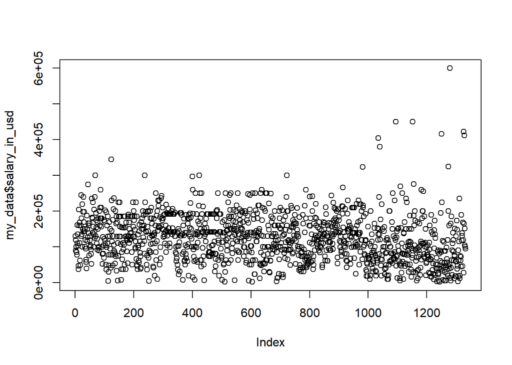

```r
plot(my_data$salary_in_usd)
```

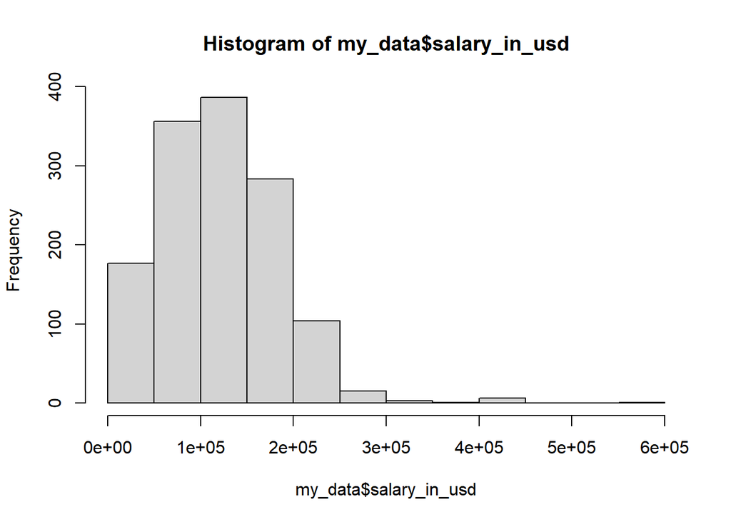

```r
hist(my_data$salary_in_usd)
```

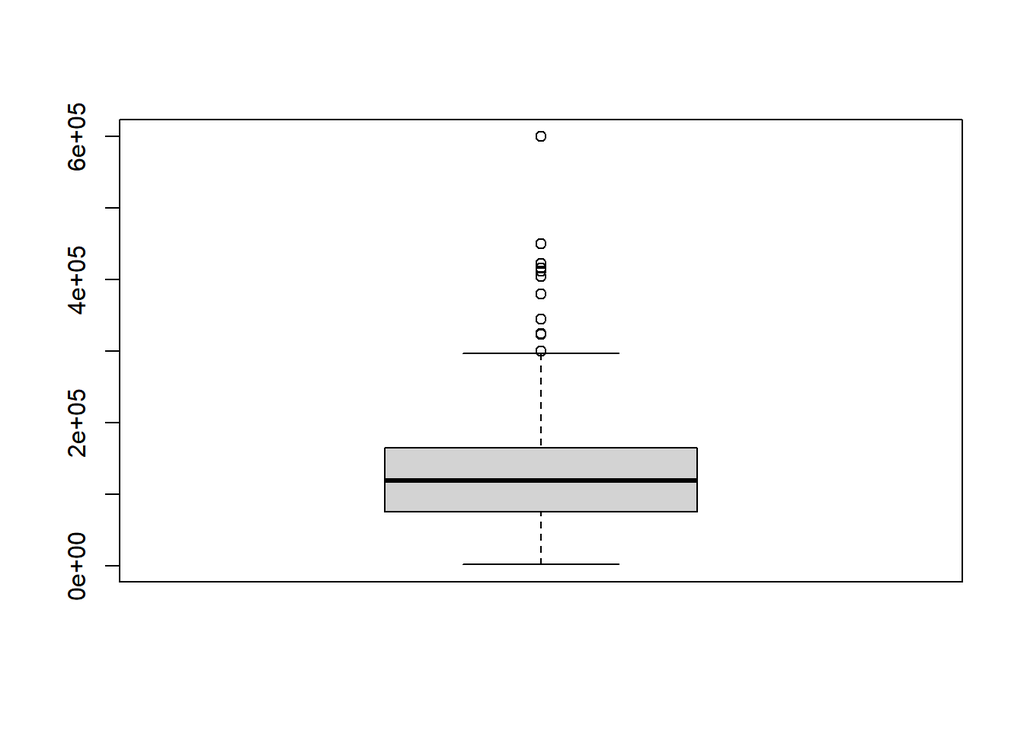

```r
#removing outliers
boxplot(my_data$salary_in_usd)
```

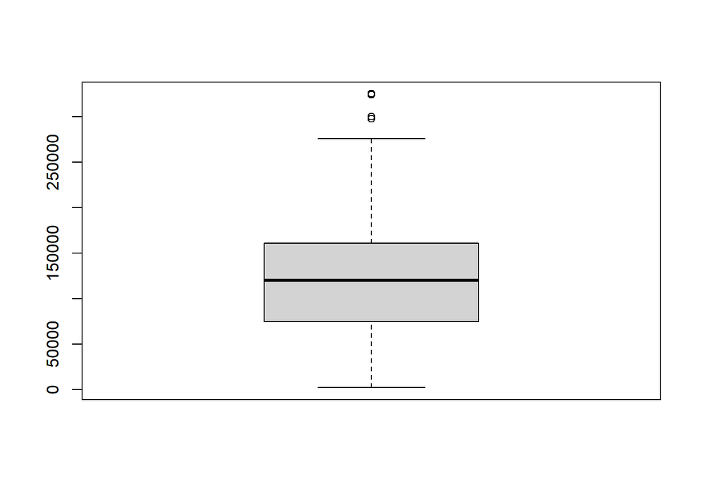

```r
quartiles1 <- quantile(my_data$salary_in_usd, probs=c(.01, .90), na.rm = FALSE)
IQR <- IQR(my_data$salary_in_usd)

Lower1 <- quartiles1[1] - 1.5*IQR
Upper1 <- quartiles1[2] + 1.5*IQR

data_no_outlier <- subset(my_data,my_data$salary_in_usd > Lower1 & my_data$salary_in_usd < Upper1)
boxplot(data_no_outlier$salary_in_usd)
```

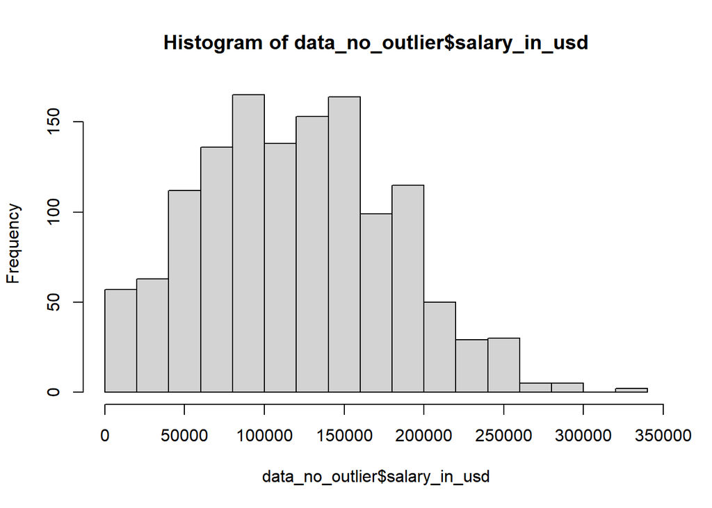

```r
hist(data_no_outlier$salary_in_usd)
```

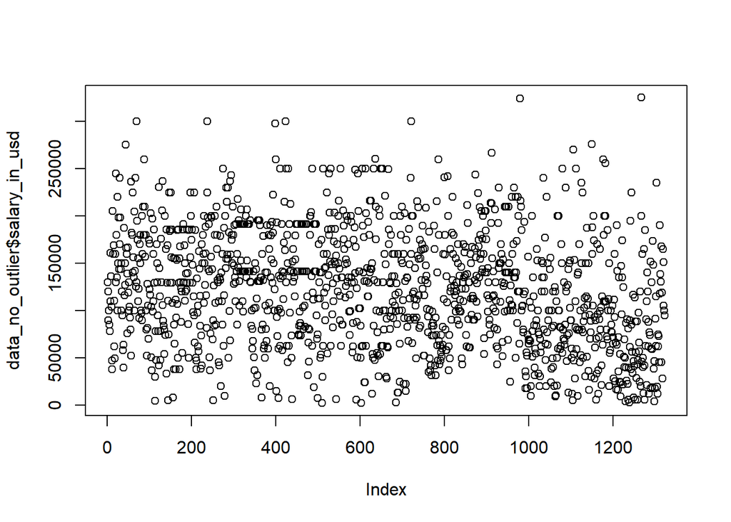

```r
plot(data_no_outlier$salary_in_usd)
```

```r
salaTitle <-  data_no_outlier[, c(4, 5)]
summary(salaTitle)
```

```
##    job_title         salary
##  Min.   : 1.00   Min.   :    2324
##  1st Qu.:21.00   1st Qu.:   80000
##  Median :22.00   Median :  130000
##  Mean   :26.79   Mean   :  236396
##  3rd Qu.:31.00   3rd Qu.:  175000
##  Max.   :64.00   Max.   :30400000
```

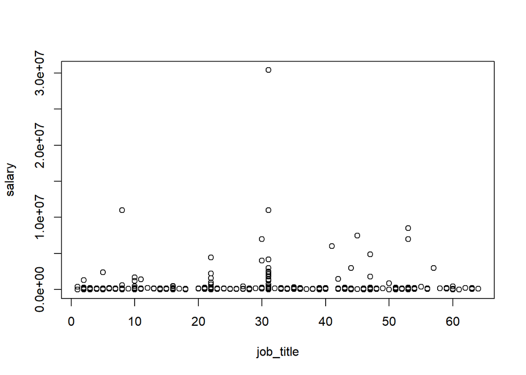

```r
plot(salaTitle)
```

```r
summary(data_no_outlier$experience_level)
```

```
##    Min. 1st Qu.  Median    Mean 3rd Qu.    Max.
##   1.000   3.000   4.000   3.349   4.000   4.000
```

```r
summary(data_no_outlier$employee_residence)
```

```
##    Min. 1st Qu.  Median    Mean 3rd Qu.    Max.
##    1.00   34.00   63.00   51.53   63.00   64.00
```

```r
summary(data_no_outlier$employment_type)
```

```
##    Min. 1st Qu.  Median    Mean 3rd Qu.    Max.
##   1.000   3.000   3.000   2.995   3.000   4.000
```

```r
summary(data_no_outlier$company_size)
```

```
##    Min. 1st Qu.  Median    Mean 3rd Qu.    Max.
##   1.000   2.000   2.000   1.845   2.000   3.000
```

```r
summary(data_no_outlier$remote_ratio)
```

```
##    Min. 1st Qu.  Median    Mean 3rd Qu.    Max.
##    0.00    0.00  100.00   63.79  100.00  100.00
```

```r
summary(data_no_outlier$job_title)
```

```
##    Min. 1st Qu.  Median    Mean 3rd Qu.    Max.
##    1.00   21.00   22.00   26.79   31.00   64.00
```

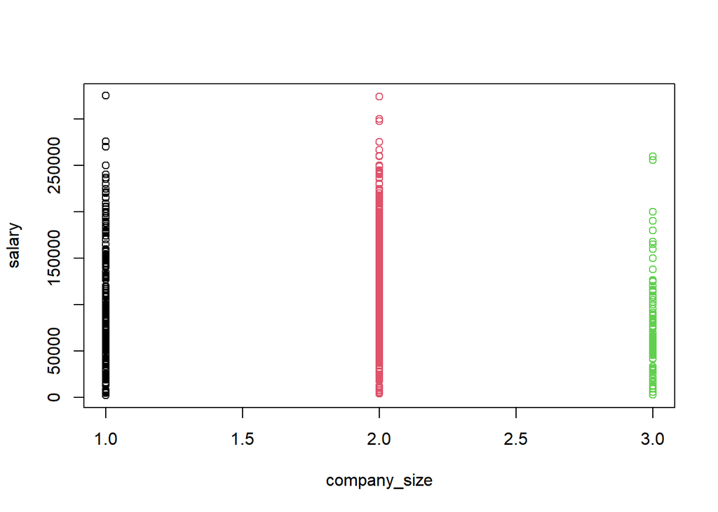

```r
plot(data_no_outlier$company_size, data_no_outlier$salary_in_usd , col=data_no_outlier$company_size, xlab="company_size", ylab="salary" )
```

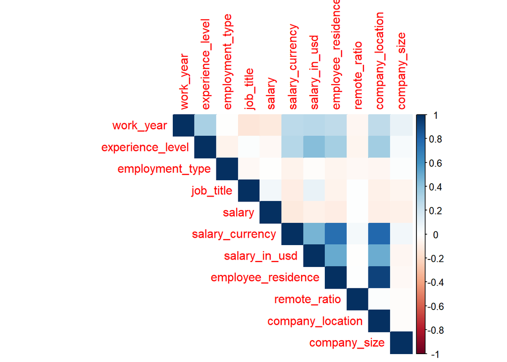

```r
corrplot(cor(data_no_outlier), method = "color", type = "upper")
```

```r
#reiniciar los datos
data_no_outlier <- read.csv("AI_MLsalaries.csv",stringsAsFactors = TRUE)

#removing outliers
quartiles1 <- quantile(data_no_outlier$salary_in_usd, probs=c(.01, .90), na.rm = FALSE)
IQR <- IQR(data_no_outlier$salary_in_usd)

Lower1 <- quartiles1[1] - 1.5*IQR
Upper1 <- quartiles1[2] + 1.5*IQR

data_no_outlier <- subset(data_no_outlier,data_no_outlier$salary_in_usd > Lower1 & data_no_outlier$salary_in_usd < Upper1)

#eliminating columns
data_no_outlier["salary"] <- NULL
data_no_outlier["employee_residence"] <- NULL
data_no_outlier["salary_currency"] <- NULL

#eliminating not FT
head(data_no_outlier)
```

```
##   work_year experience_level employment_type                 job_title
## 1      2022               MI              FT Machine Learning Engineer
## 2      2022               MI              FT Machine Learning Engineer
## 3      2022               MI              FT            Data Scientist
## 4      2022               MI              FT            Data Scientist
## 5      2022               MI              FT            Data Scientist
## 6      2022               MI              FT            Data Scientist
##   salary_in_usd remote_ratio company_location company_size
## 1        130000            0               US            M
## 2         90000            0               US            M
## 3        120000          100               US            M
## 4        100000          100               US            M
## 5         85000          100               US            M
## 6         78000          100               US            M
```

```r
data_no_outlier <- data_no_outlier[data_no_outlier$employment_type == "FT",]

#remote_ratio as factor
data_no_outlier["remote_ratio"] <- as.factor(data_no_outlier$remote_ratio)
data_no_outlier["work_year"] <- as.factor(data_no_outlier$work_year)
#NR -> no remote work, PR -> partially remote, FR -> fully remtote
levels(data_no_outlier$remote_ratio) <- list(NR  = "0", PR = "50", FR = "100")

#grouping by continents
data_no_outlier$continent <- countrycode(sourcevar = data_no_outlier[, "company_location"],
                            origin = "iso2c",
                            destination = "continent")
data_no_outlier$continent[data_no_outlier$company_location == "CA" | data_no_outlier$company_location == "US"] <- "North America"
data_no_outlier$continent = as.factor(data_no_outlier$continent)

#gruouping jobs (for clustering approach)
data_no_outlier$job_title_grouped <- data_no_outlier$job_title
data_no_outlier[grepl("BI", data_no_outlier$job_title_grouped, fixed=TRUE),]$job_title_grouped <- "BI Analyst"
data_no_outlier[grepl("Data Analy", data_no_outlier$job_title_grouped, fixed=TRUE),]$job_title_grouped <- "Data Analyst"
data_no_outlier[grepl("Sci", data_no_outlier$job_title_grouped, fixed=TRUE),]$job_title_grouped <- "Data Scientist"
data_no_outlier[grepl("Machine Learning", data_no_outlier$job_title_grouped, fixed=TRUE),]$job_title_grouped <- "ML Engineer"
data_no_outlier[grepl("Data Engi", data_no_outlier$job_title_grouped, fixed=TRUE),]$job_title_grouped <- "Data Engineer"
data_no_outlier[grepl("NLP", data_no_outlier$job_title_grouped, fixed=TRUE),]$job_title_grouped <- "Data Engineer"
data_no_outlier[grepl("Analytics", data_no_outlier$job_title_grouped, fixed=TRUE),]$job_title_grouped <- "Data Engineer"
data_no_outlier[grepl("Research", data_no_outlier$job_title_grouped, fixed=TRUE),]$job_title_grouped <- "Data Engineer"
data_no_outlier[grepl("ETL", data_no_outlier$job_title_grouped, fixed=TRUE),]$job_title_grouped <- "Data Engineer"
data_no_outlier[grepl("Data Operations", data_no_outlier$job_title_grouped, fixed=TRUE),]$job_title_grouped <- "Data Engineer"
data_no_outlier[grepl("Computer Vision", data_no_outlier$job_title_grouped, fixed=TRUE),]$job_title_grouped <- "3D Computer Vision Researcher"
data_no_outlier[grepl("Data Architect", data_no_outlier$job_title_grouped, fixed=TRUE),]$job_title_grouped <- "Data Architect"
data_no_outlier[grepl("Head of", data_no_outlier$job_title_grouped, fixed=TRUE),]$job_title_grouped <- "Data Manager"
data_no_outlier$job_title_grouped <- factor(data_no_outlier$job_title_grouped)
summary(data_no_outlier$job_title_grouped)
```

```
## 3D Computer Vision Researcher                    BI Analyst
##                             7                            17
##                  Data Analyst                Data Architect
##                           220                            39
##                 Data Engineer                  Data Manager
##                           413                            12
##                Data Scientist               Data Specialist
##                           465                             6
##                   ML Engineer
##                           119
```

```r
levels(data_no_outlier$job_title_grouped)
```

```
## [1] "3D Computer Vision Researcher" "BI Analyst"
## [3] "Data Analyst"                  "Data Architect"
## [5] "Data Engineer"                 "Data Manager"
## [7] "Data Scientist"                "Data Specialist"
## [9] "ML Engineer"
```

```r
#agrupar los precios por rangos
data_no_outlier$quartile <- ntile(data_no_outlier$salary_in_usd, 4)
data_no_outlier["quartile"] <- as.factor(data_no_outlier$quartile)
levels(data_no_outlier$quartile) <- list(Low  = "1", Medium_low = "2", Medium_high = "3", High = "4")

str(data_no_outlier)
```

```
## 'data.frame':    1298 obs. of  11 variables:
##  $ work_year        : Factor w/ 3 levels "2020","2021",..: 3 3 3 3 3 3 3 3 3 3 ...
##  $ experience_level : Factor w/ 4 levels "EN","EX","MI",..: 3 3 3 3 3 3 4 4 4 4 ...
##  $ employment_type  : Factor w/ 4 levels "CT","FL","FT",..: 3 3 3 3 3 3 3 3 3 3 ...
##  $ job_title        : Factor w/ 64 levels "3D Computer Vision Researcher",..: 47 47 31 31 31 31 22 22 31 31 ...
##  $ salary_in_usd    : int  130000 90000 120000 100000 85000 78000 161000 110000 136000 104000 ...
##  $ remote_ratio     : Factor w/ 3 levels "NR","PR","FR": 1 1 3 3 3 3 3 3 3 3 ...
##  $ company_location : Factor w/ 59 levels "AE","AL","AR",..: 58 58 58 58 58 58 58 58 58 58 ...
##  $ company_size     : Factor w/ 3 levels "L","M","S": 2 2 2 2 2 2 2 2 2 2 ...
##  $ continent        : Factor w/ 6 levels "Africa","Americas",..: 5 5 5 5 5 5 5 5 5 5 ...
##  $ job_title_grouped: Factor w/ 9 levels "3D Computer Vision Researcher",..: 9 9 7 7 7 7 5 5 7 7 ...
##  $ quartile         : Factor w/ 4 levels "Low","Medium_low",..: 3 2 2 2 2 2 3 2 3 2 ...
```

```r
head(data_no_outlier)
```

```
##   work_year experience_level employment_type                 job_title
## 1      2022               MI              FT Machine Learning Engineer
## 2      2022               MI              FT Machine Learning Engineer
## 3      2022               MI              FT            Data Scientist
## 4      2022               MI              FT            Data Scientist
## 5      2022               MI              FT            Data Scientist
## 6      2022               MI              FT            Data Scientist
##   salary_in_usd remote_ratio company_location company_size     continent
## 1        130000           NR               US            M North America
## 2         90000           NR               US            M North America
## 3        120000           FR               US            M North America
## 4        100000           FR               US            M North America
## 5         85000           FR               US            M North America
## 6         78000           FR               US            M North America
##   job_title_grouped    quartile
## 1       ML Engineer Medium_high
## 2       ML Engineer  Medium_low
## 3    Data Scientist  Medium_low
## 4    Data Scientist  Medium_low
## 5    Data Scientist  Medium_low
## 6    Data Scientist  Medium_low
```

```r
summary(data_no_outlier)
```

```
##  work_year   experience_level employment_type                     job_title
##  2020:  69   EN:135           CT:   0         Data Scientist           :339
##  2021: 213   EX: 43           FL:   0         Data Engineer            :317
##  2022:1016   MI:324           FT:1298         Data Analyst             :187
##              SE:796           PT:   0         Machine Learning Engineer: 86
##                                               Analytics Engineer       : 42
##                                               Data Architect           : 36
##                                               (Other)                  :291
##  salary_in_usd    remote_ratio company_location company_size
##  Min.   :  2324   NR:409       US     :919      L:310
##  1st Qu.: 77301   PR:128       GB     : 87      M:885
##  Median :120191   FR:761       CA     : 39      S:103
##  Mean   :122484                IN     : 34
##  3rd Qu.:164996                DE     : 33
##  Max.   :325000                ES     : 27
##                                (Other):159
##          continent        job_title_grouped        quartile
##  Africa       :  5   Data Scientist:465     Low        :325
##  Americas     : 26   Data Engineer :413     Medium_low :325
##  Asia         : 64   Data Analyst  :220     Medium_high:324
##  Europe       :233   ML Engineer   :119     High       :324
##  North America:958   Data Architect: 39
##  Oceania      : 12   BI Analyst    : 17
##                      (Other)       : 25
```

```r
summary(lm(formula = salary_in_usd ~ work_year + experience_level + job_title + remote_ratio + company_size + company_location,
           data = data_no_outlier))
```

```
##
## Call:
## lm(formula = salary_in_usd ~ work_year + experience_level + job_title +
##     remote_ratio + company_size + company_location, data = data_no_outlier)
##
## Residuals:
##     Min      1Q  Median      3Q     Max
## -127645  -22634   -1509   21389  144902
##
## Coefficients:
##                                                   Estimate Std. Error t value
## (Intercept)                                       -74844.8    48092.9  -1.556
## work_year2021                                      -5585.7     6245.8  -0.894
## work_year2022                                        518.2     6148.6   0.084
## experience_levelEX                                 76753.1     8735.7   8.786
## experience_levelMI                                 16527.0     4785.2   3.454
## experience_levelSE                                 40865.8     4771.2   8.565
## job_titleAI Scientist                             156788.4    43279.6   3.623
## job_titleAnalytics Engineer                       136922.9    41421.6   3.306
## job_titleApplied Data Scientist                   156980.3    44926.3   3.494
## job_titleApplied Machine Learning Scientist       106268.4    44148.4   2.407
## job_titleApplied Scientist                        162130.1    45680.5   3.549
## job_titleBI Analyst                               166804.4    46719.5   3.570
## job_titleBI Data Analyst                          107412.7    42805.3   2.509
## job_titleBig Data Architect                       134366.0    58265.5   2.306
## job_titleBig Data Engineer                        140025.8    43989.6   3.183
## job_titleBusiness Data Analyst                    133740.3    44163.8   3.028
## job_titleCloud Data Architect                     252398.3    57727.1   4.372
## job_titleCloud Data Engineer                      163844.3    52629.5   3.113
## job_titleComputer Vision Engineer                 109593.7    46593.3   2.352
## job_titleComputer Vision Software Engineer        158142.7    47522.6   3.328
## job_titleData Analyst                             111959.0    41016.8   2.730
## job_titleData Analytics Consultant                126234.8    57789.8   2.184
## job_titleData Analytics Engineer                  123281.9    45062.5   2.736
## job_titleData Analytics Manager                   119070.1    43556.6   2.734
## job_titleData Architect                           154209.9    41420.2   3.723
## job_titleData Engineer                            142624.8    40950.7   3.483
## job_titleData Engineering Manager                 150610.6    44061.7   3.418
## job_titleData Manager                             125991.1    45008.9   2.799
## job_titleData Operations Analyst                   79315.9    45690.5   1.736
```

[output cut: 217 more lines]

```
## company_locationRO                                0.918630
## company_locationRU                                0.783944
## company_locationSG                                0.801282
## company_locationSI                                0.235059
## company_locationTH                                0.391375
## company_locationTR                                0.042726 *
## company_locationUA                                0.317479
## company_locationUS                                0.056284 .
## company_locationVN                                0.222451
## ---
## Signif. codes:  0 '***' 0.001 '**' 0.01 '*' 0.05 '.' 0.1 ' ' 1
##
## Residual standard error: 40660 on 1171 degrees of freedom
## Multiple R-squared:  0.5887, Adjusted R-squared:  0.5444
## F-statistic:  13.3 on 126 and 1171 DF,  p-value: < 2.2e-16
```

# CLUSTERING

## Manual Distance matrix

First of all, for us to be able to apply clustering techniques to our Job Titles, we need to create a Distance Matrix which will be used as an input in the clustering methods. To generate this Distance Matrix, we have had to investigate and do some research to deeply understand what these Job Titles consist of so we can actually know how similar they are one to another. Once we have done this first step, we have created a distance scale in which the value 0 represents total similarity between 2 Job Titles (therefore, their distance will be 0) and the value 1 represents that 2 Job Titles are completely opposite. So, with this distance scale and the research done previously, the Distance Matrix generated is the following:

|  | Computer_Vision | Business_Intelligence | Data_Analyst | Data_Architect | Data_Engineer | CPO | Data_Scientist | Data_Specialist | Machine_Learning |
| --- | --- | --- | --- | --- | --- | --- | --- | --- | --- |
| Computer_Vision | 0.00 | 0.75 | 0.75 | 0.75 | 0.80 | 0.90 | 0.75 | 0.75 | 0.25 |
| Business_Intelligence | 0.75 | 0.00 | 0.30 | 0.40 | 0.40 | 0.75 | 0.30 | 0.40 | 0.50 |
| Data_Analyst | 0.75 | 0.30 | 0.00 | 0.25 | 0.25 | 0.75 | 0.15 | 0.30 | 0.50 |
| Data_Architect | 0.75 | 0.40 | 0.25 | 0.00 | 0.10 | 0.75 | 0.25 | 0.30 | 0.40 |
| Data_Engineer | 0.80 | 0.40 | 0.25 | 0.10 | 0.00 | 0.80 | 0.30 | 0.30 | 0.40 |
| CPO | 0.90 | 0.75 | 0.75 | 0.75 | 0.80 | 0.00 | 0.80 | 0.80 | 0.85 |
| Data_Scientist | 0.75 | 0.30 | 0.15 | 0.25 | 0.30 | 0.80 | 0.00 | 0.15 | 0.50 |
| Data_Specialist | 0.75 | 0.40 | 0.30 | 0.30 | 0.30 | 0.80 | 0.15 | 0.00 | 0.50 |
| Machine_Learning | 0.25 | 0.50 | 0.50 | 0.40 | 0.40 | 0.85 | 0.50 | 0.50 | 0.00 |

## Graphical visualization of the Job Titles by distance of the Distance Matrix

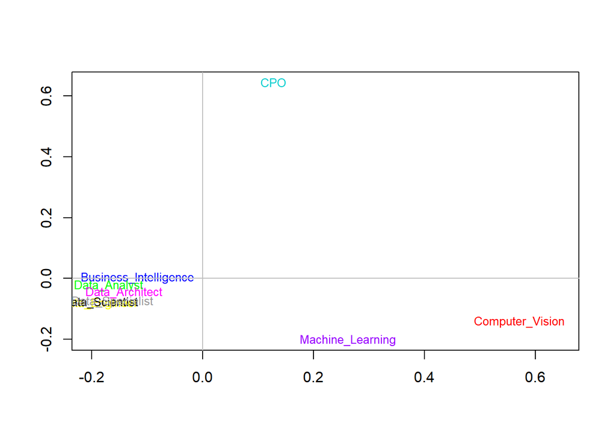

## Hierarchical Clustering using the Distance matrix of the Job Titles

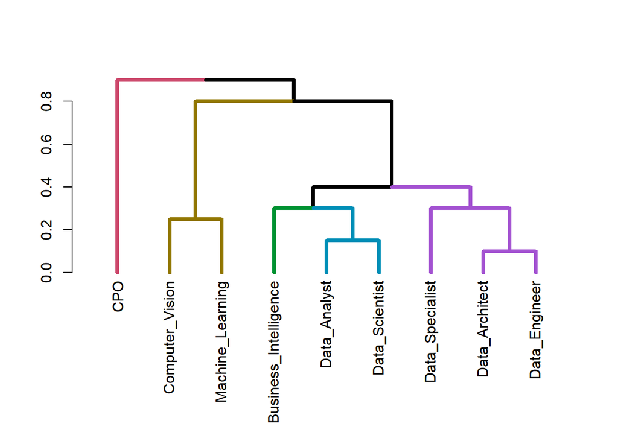

## K-Means using Distance matrix of the Job Titles

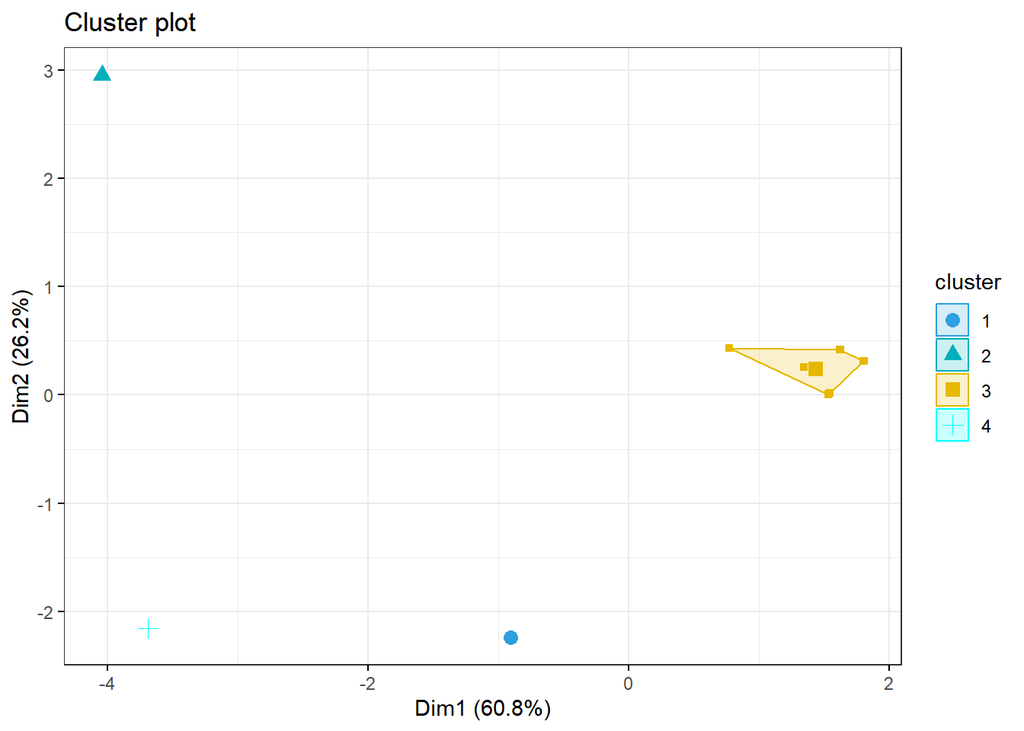